# City of Raileigh Analysis

Name Sriranganath Shankam Manjunatha Prasanna

```r
library(dplyr)
library(caTools)
library(tidyverse)
library(caret)
```

```r
#loading the Dataset
raileigh = read.csv("Building_Permits.csv")
```

```r
#No of rows and coumns respectively
nrow(raileigh)
```

```
[1] 141953
```

```r
ncol(raileigh)
```

```
[1] 87
```

```r
#Total Different Types of Construction
unique(raileigh$const_type, incomparables = FALSE)
```

```
 [1] V  B      II B II A IIIB I  A I  B IV   V  A IV U VI U V  U VI P V  P IIIA I    III  II   IV P
Levels:  I I  A I  B II II A II B III IIIA IIIB IV IV P IV U V  A V  B V  P V  U VI P VI U
```

```r
#Mean and Median Stories
no_na_stories = na.omit(raileigh$numberstories) #removing blanks
summary(raileigh$numberstories)
```

```
    Min.  1st Qu.   Median     Mean  3rd Qu.     Max.     NA's
     0.0      1.0      2.0      9.7      2.0 342365.0    19511
```

Intial Linear Regression for the Data columns Estimated cost and Issue Date year for raw data

```r
initial_pred=lm(estprojectcost~issueddate_yr,data=raileigh)
summary(initial_pred)
```

```
Call:
lm(formula = estprojectcost ~ issueddate_yr, data = raileigh)

Residuals:
      Min        1Q    Median        3Q       Max
  -210069   -176009   -128066    -41855 169811934

Coefficients:
                Estimate Std. Error t value Pr(>|t|)
(Intercept)   -5340098.2  1399266.5  -3.816 0.000135 ***
issueddate_yr     2750.3      696.6   3.948 7.87e-05 ***
---
Signif. codes:  0 ‘***’ 0.001 ‘**’ 0.01 ‘*’ 0.05 ‘.’ 0.1 ‘ ’ 1

Residual standard error: 1422000 on 138517 degrees of freedom
  (3434 observations deleted due to missingness)
Multiple R-squared:  0.0001125, Adjusted R-squared:  0.0001053
F-statistic: 15.59 on 1 and 138517 DF,  p-value: 7.871e-05
```

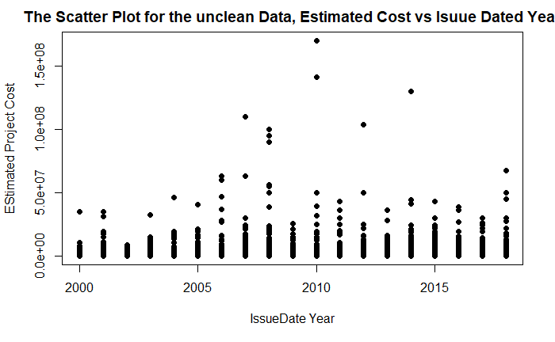

```r
#Scatter Plot for Estimated Cost
plot(raileigh$issueddate_yr,raileigh$estprojectcost,pch=19,main="The Scatter Plot for the unclean Data, Estimated Cost vs Isuue Dated Year",xlab = "IssueDate Year", ylab = "EStimated Project Cost")
```

# Standard Deviation of X and Y of permits

```r
sd(raileigh$ï..X, na.rm = TRUE)
```

```
[1] 0.06880534
```

```r
sd(raileigh$Y, na.rm = TRUE)
```

```
[1] 0.05839208
```

# Estimate cost

```r
range(raileigh$estprojectcost)
```

```
[1] 0.0e+00 1.7e+08
```

```r
summary(raileigh$estprojectcost) #Checking the range and summaryfor knowing the end values of Estimated cost
```

```
    Min.  1st Qu.   Median     Mean  3rd Qu.     Max.
0.00e+00 1.00e+04 5.44e+04 1.92e+05 1.35e+05 1.70e+08
```

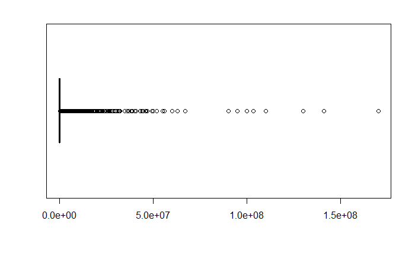

```r
boxplot(raileigh$estprojectcost,horizontal=TRUE)  # BoXplot to see how there are so many outliers
```

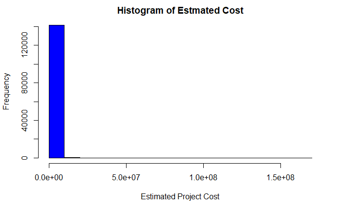

```r
hist(raileigh$estprojectcost, main = "Histogram of Estmated Cost",xlab = "Estimated Project Cost", col = "Blue") # Histogram of Estimated Cost
```

This shows the range of the Estimated Project Cost, as the data has very high outliers were getting one big bar on the histogram, so we can remove the outliers and check for the distribution of this field. Box plot also shows the same as well. How the data is positively skewed.

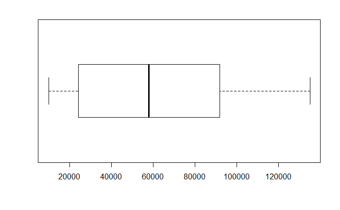

```r
#Filtering the Estimate cost by Inter quartile range to show the Distribution of Estimated Cost
filtered_estimate<-raileigh %>%
  dplyr::filter(estprojectcost > quantile(estprojectcost, 0.25),
                estprojectcost < quantile(estprojectcost, 0.75))
boxplot(filtered_estimate$estprojectcost,horizontal=T)
```

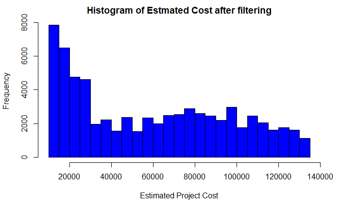

```r
hist(filtered_estimate$estprojectcost, main = "Histogram of Estmated Cost after filtering",xlab = "Estimated Project Cost", col = "Blue")
```

```r
#Issue Date Month
no_na_issuedatemth = na.omit(raileigh$issueddate_mth) #Removing NA values in Issue date Month
summary(no_na_issuedatemth)
```

```
   Min. 1st Qu.  Median    Mean 3rd Qu.    Max.
  1.000   4.000   6.000   6.407   9.000  12.000
```

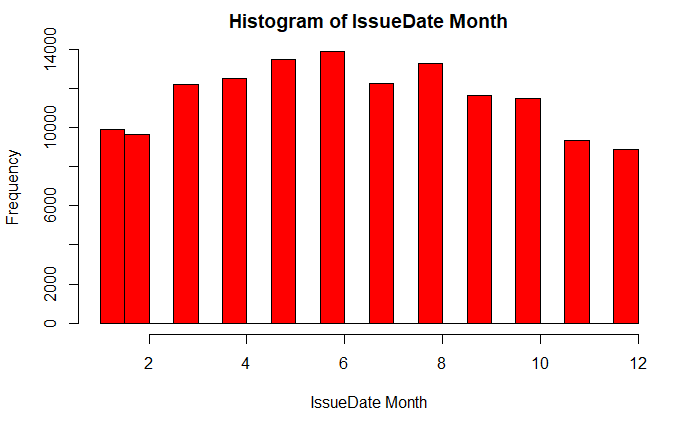

```r
hist(no_na_issuedatemth,main = "Histogram of IssueDate Month",xlab = "IssueDate Month", col = "Red")
```

I have handled the null values for the Issue month and have plotted the histogram. we can see thatmore projects have been issue in the months of 4-8 in any given year.

```r
#Filtering the data for Workclass = "New", Construction Type ="V  B" and Number of Stories is less than 3
filtered_raileigh = filter(raileigh, workclassmapped=="New" & const_type=="V  B" & numberstories < 3)
range(filtered_raileigh$issueddate_yr) #checking the range of Issue date year
```

```
[1] NA NA
```

Were filetering the data acconding to the conditions Workclass = “New”, Construction Type =“V B” and Number of Stories is less than 3 Also were checking the issuedate year range, as we can see its shows NA, because it has a lot of NA values. No lwts handle it

```r
#Finding NA values in both our values for Regression, and replacing the NA values by mean of the other values.
filtered_raileigh$estprojectcost = ifelse(is.na(filtered_raileigh$estprojectcost),ave(filtered_raileigh$estprojectcost, FUN = function(x) mean(x,na.rm=TRUE)),filtered_raileigh$estprojectcost)
filtered_raileigh$issueddate_yr = ifelse(is.na(filtered_raileigh$issueddate_yr),ave(filtered_raileigh$issueddate_yr, FUN = function(x) mean(x,na.rm=TRUE)),filtered_raileigh$issueddate_yr)
range(filtered_raileigh$issueddate_yr)  #checking after replacing NA values
```

```
[1] 2002 2018
```

So now its shows the highes year and the lowest year in the coulumn.

```r
range(filtered_raileigh$estprojectcost) #range of projectcost
```

```
[1] 0e+00 1e+08
```

# Sampling the whole filetered data set and splitting into 75% train and 25% into test data

```r
smp_size <- floor(0.75 * nrow(filtered_raileigh))
set.seed(2196) # Set the seed to make your partition reproducible
train_ind <- sample(seq_len(nrow(filtered_raileigh)), size = smp_size)
train_raileigh <- filtered_raileigh[train_ind, ]
test_raileigh <- filtered_raileigh[-train_ind, ]
```

# Linear Regression with Train dataset without cleaning

```r
raileigh_pred=lm(estprojectcost~issueddate_yr,data=train_raileigh)
summary(raileigh_pred)
```

```
Call:
lm(formula = estprojectcost ~ issueddate_yr, data = train_raileigh)

Residuals:
     Min       1Q   Median       3Q      Max
 -332336   -87718   -43393    27559 99789843

Coefficients:
               Estimate Std. Error t value Pr(>|t|)
(Intercept)   -25034959    2818097  -8.884   <2e-16 ***
issueddate_yr     12572       1403   8.960   <2e-16 ***
---
Signif. codes:  0 ‘***’ 0.001 ‘**’ 0.01 ‘*’ 0.05 ‘.’ 0.1 ‘ ’ 1

Residual standard error: 982600 on 23281 degrees of freedom
Multiple R-squared:  0.003436,  Adjusted R-squared:  0.003394
F-statistic: 80.28 on 1 and 23281 DF,  p-value: < 2.2e-16
```

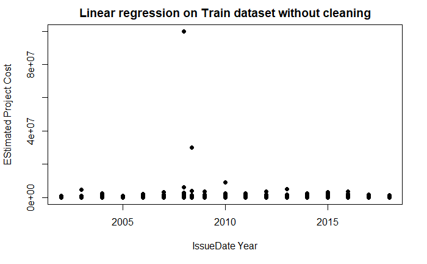

```r
plot(train_raileigh$issueddate_yr,train_raileigh$estprojectcost,pch=19,main="Linear regression on Train dataset without cleaning",xlab = "IssueDate Year", ylab = "EStimated Project Cost")
```

Because of the high range of data and the outlier, which can be seen of the scatter plot we can see much of relation between our variable chosen for Regressio. The P-values for the intercept shows that, IssueDat year (inedependent variable) has some kinda relation with our Dependent Variable (Estimated Cost). But due to the high error of an 982600 and the R square value of 0.003 we can say that this model is not a right fit for these selected variables.

# Filtering Train Data, by multiplying the interquartile range by the number 1.5 and adding it to the third quartile and subrtracting it from the first quartile. Any number less than this is a suspected outlier.

```r
filtered_train<-train_raileigh %>%
  dplyr::filter(estprojectcost > quantile(train_raileigh$estprojectcost, .25) - 1.5*IQR(train_raileigh$estprojectcost),
                train_raileigh$estprojectcost < quantile(train_raileigh$estprojectcost, .75) + 1.5*IQR(train_raileigh$estprojectcost))
```

```r
raileigh_pred2=lm(estprojectcost~issueddate_yr,data=filtered_train)
summary(raileigh_pred2)
```

```
Call:
lm(formula = estprojectcost ~ issueddate_yr, data = filtered_train)

Residuals:
    Min      1Q  Median      3Q     Max
-268005  -60033  -16548   49421  343667

Coefficients:
                Estimate Std. Error t value Pr(>|t|)
(Intercept)   -1.922e+07  2.828e+05  -67.96   <2e-16 ***
issueddate_yr  9.658e+03  1.408e+02   68.59   <2e-16 ***
---
Signif. codes:  0 ‘***’ 0.001 ‘**’ 0.01 ‘*’ 0.05 ‘.’ 0.1 ‘ ’ 1

Residual standard error: 95490 on 22205 degrees of freedom
Multiple R-squared:  0.1748,    Adjusted R-squared:  0.1748
F-statistic:  4704 on 1 and 22205 DF,  p-value: < 2.2e-16
```

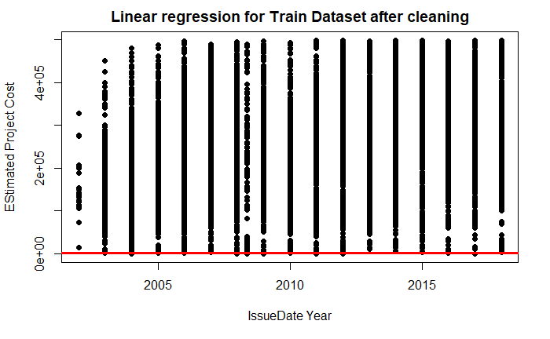

```r
plot(filtered_train$issueddate_yr,filtered_train$estprojectcost,pch=19,main="Linear regression for Train Dataset after cleaning",xlab = "IssueDate Year", ylab = "EStimated Project Cost")
abline(0,1,col="red",lwd=3)
```

```r
#Predicting values on Test Dataset
predictions <- predict(raileigh_pred2,test_raileigh)
output <- cbind(test_raileigh, predictions)
actuals_preds <- data.frame(cbind(actuals=test_raileigh$estprojectcost, predicteds=predictions))
```

# Plotting Actual vs Predicted with test data

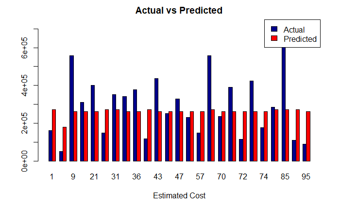

```r
mx <- t(as.matrix(ab[-3]))
ab = head(actuals_preds,n=25)
barplot(mx,main="Actual vs Predicted", xlab='Estimated Cost',beside = TRUE,
        col=c("darkblue","red"))
legend('topright',fill=c("darkblue","red"),legend=c('Actual','Predicted')) # add a legend
```

As we can see the Data is predicting value is similar range, and when compared to the actual data, it is nowhere close.

Thank you for your time.